# Springfield research

## **Introduction**

The rapid expansion of human settlements and the resulting urbanization are major drivers of environmental change globally (De Barros Ruas et al., 2022). As natural landscapes are converted into urban infrastructures, local ecosystems face significant disruption, leading to changes in soil composition, hydrology, and temperature (Gioria & Osborne, 2014). These disturbances often create favorable conditions for plant species that are highly adaptable and competitive, known as invasive flora, while simultaneously stressing native or established plant communities (Trentanovi et al., 2013). Understanding the direct ecological consequences of this historical shift is crucial for conservation and urban planning efforts.

While research has highlighted the broad ecological consequences of urbanization, there remains a need to investigate specific regional effects; specifically, this study focuses on documenting the impact of major urbanization in Springfield, Massachusetts, that occurred between the mid-19th and late-20th centuries on the local plant communities. While it is theorized that urbanization promotes invasive species and diminishes native populations, a direct, comparative analysis using historical datasets across this critical period provides essential evidence.

The objective of this investigation is to statistically compare the diversity and population size of invasive and native/established flora species across two distinct historical periods: 1840-1880 (pre-major urbanization) and 1960-2000 (post-major urbanization). By analyzing archived data from the Consortium of Northeastern Herbaria, we aim to quantify the shifts in plant populations. We hypothesize that the increase in invasive species will be statistically significant and will coincide with a corresponding statistically significant decline in native flora, suggesting a causal relationship driven by urban development.

### Methods:

The database provided by Faber-Langendoen, D. 2018. Northeast Regional Floristic Quality Assessment Tools for Wetland Assessments. NatureServe, Arlington, VA. Contributing Authors: Don Cameron, Arthur V. Gilman, Kenneth J. Metzler, Richard M. Ring, Michele Bottiaux, Kristin Snow, Lesley Sneddon were then used. This was done to obtain coefficients of conservatism, or C values, based on their response to stressors. Species with high C values (7-10) are mostly confined to areas with minimal anthropogenic disturbance or adapted to unique natural conditions (including natural disturbances), while species with low C values (1-3) are mostly found in ruderal or highly degraded habitats. Exotic species are typically assigned a value of 0.

```r
library(dplyr)
library(ggplot2)
library(scales)
```

```r
info <- data.frame(
  period = c("Before (1840–1880)", "Before (1840–1880)",
             "After (1960–2000)",  "After (1960–2000)"),
  status = c("Native", "Non-native", "Native", "Non-native"),
  n      = c(25, 9, 65, 38)
)

info$period <- factor(info$period, levels = c("Before (1840–1880)", "After (1960–2000)"))
info$status <- factor(info$status, levels = c("Native", "Non-native"))

info_prop <- info %>%
  group_by(period) %>%
  mutate(prop = n / sum(n)) %>%
  ungroup()
```

### Graphs

```r
pal <- c("Native"="darkseagreen3","Non-native"="steelblue1")

base_theme <- theme_minimal(base_size = 12) +
  theme(
    plot.title    = element_text(face = "bold", hjust = 0.5),
    plot.subtitle = element_text(hjust = 0.5, color = "#555"),
    panel.grid.minor = element_blank(),
    panel.grid.major.x = element_blank()
  )
```

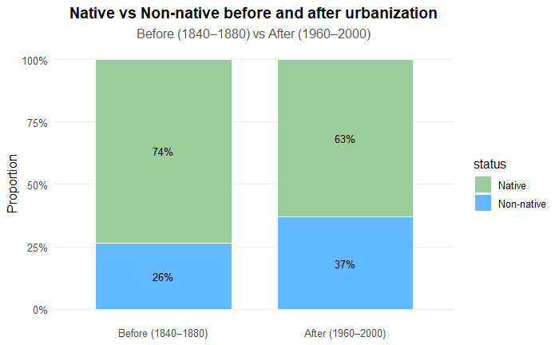

```r
graph1 <- ggplot(info_prop, aes(x = period, y = prop, fill = status)) +
  geom_col(position = "fill", width = 0.75, color = "white") +
  geom_text(aes(label = percent(prop, accuracy = 1)),
            position = position_stack(vjust = 0.5), size = 3.5) +
  scale_y_continuous(labels = percent_format(accuracy = 1)) +
  scale_fill_manual(values = pal) +
  labs(title = "Native vs Non-native before and after urbanization",
       subtitle = "Before (1840–1880) vs After (1960–2000)",
       x = NULL, y = "Proportion") +
  base_theme

graph1
```

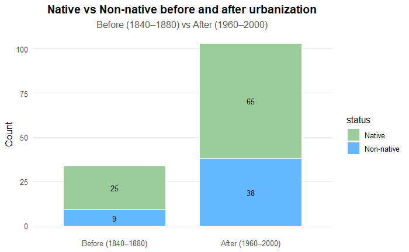

```r
graph2 <- ggplot(info, aes(x = period, y = n, fill = status)) +
  geom_col(width = 0.75, color = "white") +
  geom_text(aes(label = n), position = position_stack(vjust = 0.5), size = 3.5) +
  scale_fill_manual(values = pal) +
  labs(title = "Native vs Non-native before and after urbanization",
       subtitle = "Before (1840–1880) vs After (1960–2000)",
       x = NULL, y = "Count") +
  base_theme

graph2
```

#### CHI SQUARE TEST OF NATIVE VS NON NATIVE PLANTS

```r
tab <- matrix(c(25, 9,
                65, 38),
              nrow = 2, byrow = TRUE,
              dimnames = list(Period = c("Before","After"),
                              Status = c("Native","Non-native")))
chisq.test(tab)
```

```
    Pearson's Chi-squared test with Yates' continuity correction

data:  tab
X-squared = 0.81304, df = 1, p-value = 0.3672
```

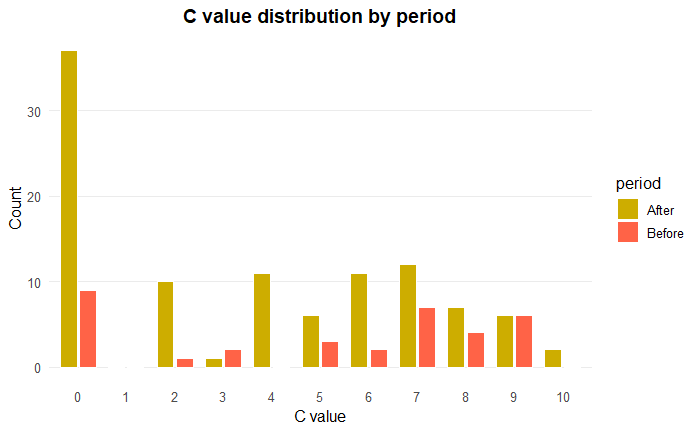

```r
C_value <- 0:10

before_c <- c(9, 0, 1, 2, 0, 3, 2, 7, 4, 6, 0) #34 total
after_c  <- c(37,0,10, 1,11, 6,11,12,7, 6, 2) #103 total

c_data <- data.frame(
  C_value = rep(C_value, 2),
  period  = rep(c("Before","After"), each = length(C_value)),
  n       = c(before_c, after_c)
)


pal <- c("Before" = "tomato1", "After" = "gold3")

base_theme <- theme_minimal(base_size = 12) +
  theme(
    plot.title    = element_text(face = "bold", hjust = 0.5),
    plot.subtitle = element_text(hjust = 0.5, color = "#555"),
    panel.grid.minor = element_blank(),
    panel.grid.major.x = element_blank()
)

graph3 <- ggplot(c_data, aes(x = factor(C_value), y = n, fill = period)) +
  geom_col(position = position_dodge(width = 0.8), width = 0.7, color = "white") +
  scale_fill_manual(values = pal) +
  labs(title = "C value distribution by period", x = "C value", y = "Count") +
  theme_minimal(base_size = 12) + base_theme


graph3
```

#### T TEST OF C VALUES BEFORE AND AFTER URBANIZATION IN SPRINGFIELD

```r
c_before <- rep(C_value, times = before_c)
c_after  <- rep(C_value, times = after_c)
t.test(c_before, c_after)
```

```
    Welch Two Sample t-test

data:  c_before and c_after
t = 1.9626, df = 53.771, p-value = 0.05487
alternative hypothesis: true difference in means is not equal to 0
95 percent confidence interval:
 -0.02897295  2.70858460
sample estimates:
mean of x mean of y
 5.000000  3.660194
```